# Introduction to SC19035

## Answer

When nx != ny, using m =5 as the critical value for both Cx and Cy may not be acceptable. We can ﬁnd an appropriate critical value for Cx by substituting different values of m=5 until we ﬁnd one resulting in aprobability that is approximately α/2. The formula is

$$P(Cx>=m0/H0)=ln(nx/(nx+ny))*m$$

```r
n1 <- 10
n2 <- 20
mu1 <- mu2 <- 0
sigma1 <- sigma2 <- 1
m <- 1000


##Estimate the m

alpha<-0.06
mx<-log(alpha/2)/log(n1/(n1+n2))
my<-log(alpha/2)/log(n2/(n1+n2))
print(c(mx,my))#choose the bigger my
```

```
## [1] 3.191807 8.648236
```

```r
# the critical value for both Cx,cy is m=8
counttest <- function(x, y) {
  X <- x - mean(x)
  Y <- y - mean(y)
  outx <- sum(X > max(Y)) + sum(X < min(Y))
  outy <- sum(Y > max(X)) + sum(Y < min(X)) # return 1 (reject) or 0 (do not reject H0)
  return(as.integer(max(c(outx, outy)) > 8))
  }


tests <- replicate(m, expr = {
  x <- rnorm(n1, mu1, sigma1)
  y <- rnorm(n2, mu2, sigma2)
  x <- x - mean(x) #centered by sample mean
  y <- y - mean(y)
  counttest(x, y) })
alphahat <- mean(tests)
print(alphahat)
```

```
## [1] 0.028
```

## Question 2

Power comparison (distance correlation test versus ball covariance test) Model1: Y =X/4+e Model2: Y =X/4×e X ∼ N(02, I2), e ∼ N(02, I2), X and e are independent. ## Answer

```r
library(boot)
library(Ball)
library(MASS)
```

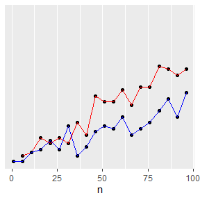

```r
library(ggplot2)
alpha <- 0.05
n<-c(seq(1,100,5))
k<-50
#denefite the statistic of cov,ndcov2

dCov <- function(x, y) {
  x <- as.matrix(x)
  y <- as.matrix(y)
  n <- nrow(x)
  m <- nrow(y)
  if (n != m || n < 2) stop("Sample sizes must agree")
  if (! (all(is.finite(c(x, y))))) stop("Data contains missing or infinite values")

  Akl <- function(x) {
    d <- as.matrix(dist(x))
    m <- rowMeans(d)
    M <- mean(d)
    a <- sweep(d, 1, m)
    b <- sweep(a, 2, m)
    return(b + M)
    }
  A <- Akl(x)
  B <- Akl(y)
  dCov <- sqrt(mean(A * B))
  dCov
}


ndCov2 <- function(z, ix, dims) { #dims contains dimensions of x and y
  p <- dims[1]
  q <- dims[2]
  d <- p + q
  x <- z[ , 1:p] #leave x as is
  y <- z[ix, -(1:p)] #permute rows of y
  return(nrow(z) * dCov(x, y)^2)
  }


set.seed(1001)


pow_dCor_Model1<-pow_ball_Model1<-pow_dCor_Model2<-pow_ball_Model2<-numeric(length(n))
dcor1<-dcor2<-p_ball1<-p_ball2<-numeric(k)

for (j in 1:length(n)) {
  dcor1 <-p_ball1< -numeric(k)
  for (i in 1:k) {
    set.seed(i)
    # the function "rmvnorm" is used to
    # generate the multidimensional normal data
    X<-mvrnorm(n[j],rep(0,2),diag(2))
    e<-mvrnorm(n[j],rep(0,2),diag(1,2))
    Y1<-(X/4)+e
    Z1<-cbind(X,Y1)

     t1<-bcov.test(X,Y1,R=99)
    p_ball1[i]<-t1$p.value
    boot.obj1<-boot(data=Z1,statistic=ndCov2,R=99,sim="permutation",dims=c(2, 2))
    temp1<-c(boot.obj1$t0, boot.obj1$t)
    dcor1[i]<-mean(temp1>=temp1[1])
    }
  pow_dCor_Model1[j]<-mean(dcor1<alpha)
  pow_ball_Model1[j]<-mean(p_ball1<alpha)
}
dat1<-data.frame(pow_dCor_Model1,pow_ball_Model1)

ggplot(dat1,aes(n))+geom_point(y=pow_dCor_Model1,fill="white")+geom_line(y=pow_dCor_Model1,colour="red")+geom_point(y=pow_ball_Model1,fill="white")+geom_line(y=pow_ball_Model1,colour="blue")
```

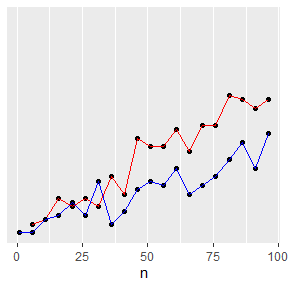

```r
for (j in 1:length(n)) {
dcor2<- p_ball2<-numeric(k)
for (i in 1:k) {
    set.seed(i)
    # the function "rmvnorm" is used to
    # generate the multidimensional normal data
    X<-mvrnorm(n[j],rep(0,2),diag(2))
    e<-mvrnorm(n[j],rep(0,2),diag(2))
    Y2<-(X/4)*e
    Z2<-cbind(X,Y2)

 t2<-bcov.test(X,Y2,R=99)
    p_ball2[i]<-t2$p.value
    boot.obj2<-boot(data=Z2,statistic=ndCov2,R=200,sim="permutation",dims=c(2, 2))
    temp2<-c(boot.obj2$t0, boot.obj2$t)
    dcor2[i]<-mean(temp2>=temp2[1])
}
  pow_dCor_Model2[j]<-mean(dcor2<alpha)
  pow_ball_Model2[j]<-mean(p_ball2<alpha)
  }
dat2<-data.frame(pow_dCor_Model2,pow_ball_Model2)


ggplot(dat2,aes(n))+geom_point(y=pow_dCor_Model1,fill="white")+geom_line(y=pow_dCor_Model1,colour="red")+geom_point(y=pow_ball_Model1,fill="white")+geom_line(y=pow_ball_Model1,colour="blue")
```

# HW8(2019/12/06)

## Questiion1

## Answer

```r
x<-c(10,20,50,100,1000)
log(exp(x))==exp(log(x))
```

```
## [1] FALSE FALSE FALSE FALSE FALSE
```

```r
exp(log(x))==x
```

```
## [1] FALSE FALSE FALSE FALSE FALSE
```

```r
log(exp(x))==x
```

```
## [1]  TRUE  TRUE  TRUE  TRUE FALSE
```

From the result,we can know that the property :log(expx) = exp(logx)=x does not hold exactly in computer arithmetic

```r
x<-c(10,20,50,100,1000)
isTRUE(all.equal(log(exp(x)), x,exp(log(x))))
```

```
## [1] FALSE
```

```r
all.equal(log(exp(x)),x,exp(log(x)))
```

```
## [1] "Mean absolute difference: Inf"
```

According to the above, the identity doesn’t hold with near equality

## Exercise 11.5

Write a function to solve the equation
$$\begin{aligned} \frac{2 \Gamma\left(\frac{k}{2}\right)}{\sqrt{\pi(k-1)} \Gamma\left(\frac{k-1}{2}\right)} \int_{0}^{c_{k-1}}\left(1+\frac{u^{2}}{k-1}\right)^{-k / 2} d u \\=& \frac{2 \Gamma\left(\frac{k+1}{2}\right)}{\sqrt{\pi k} \Gamma\left(\frac{k}{2}\right)} \int_{0}^{c_{k}}\left(1+\frac{u^{2}}{k}\right)^{-(k+1) / 2} d u \\ \text { for } a, \text { where } & \\ c_{k} &=\sqrt{\frac{a^{2} k}{k+1-a^{2}}} \end{aligned}$$
Compare the solutions with the points A(k) in Exercise 11.4.

```r
#11.5

f = function(a,k){

 ck = sqrt(a^2*k/(k+1-a^2))
 l1 = integrate(function(u){(1+u^2/k)^(-(k+1)/2)},0,ck)$value
 l2 = 2/sqrt(pi*k)*exp(lgamma((k+1)/2)-lgamma(k/2))
 l1*l2
}

solve1 = function(k){

  output = uniroot(function(a){f(a,k)-f(a,k-1)},lower=1,upper=2)
  output$root
}

k = c(4,25,100,500,1000)
root1 = matrix(0,2,length(k))

for (i in 1:length(k)){
  root1[2,i]=round(solve1(k[i]),4)
}

root1[1,] = k
rownames(root1) = c('k','root')
root1
```

```
##        [,1]    [,2]     [,3]     [,4]      [,5]
## k    4.0000 25.0000 100.0000 500.0000 1000.0000
## root 1.4921  1.6874   1.7206   1.7298    1.7309
```

```r
#11.4

S = function(a,k){

 ck = sqrt(a^2*k/(k+1-a^2))
 pt(ck,df=k,lower.tail=FALSE)
}

solve2 = function(k){
  output = uniroot(function(a){S(a,k)-S(a,k-1)},lower=1,upper=2)
  output$root
}

root2 = matrix(0,2,length(k))

for (i in 1:length(k)){
  root2[2,i]=round(solve2(k[i]),4)
}

root2[1,] = k
rownames(root2) = c('k','A(k)')
root2
```

```
##        [,1]    [,2]     [,3]     [,4]      [,5]
## k    4.0000 25.0000 100.0000 500.0000 1000.0000
## A(k) 1.4921  1.6874   1.7206   1.7298    1.7309
```

## Answer

Because of the observed data, we can rewrite the table as:

| Genotype | Frequency | Count |
| --- | --- | --- |
| AA | p2 | nAA |
| BB | q2 | nBB |
| OO | r2 | 41 |
| AO | 2pr | 28-nAA |
| BO | 2qr | 24-nBB |
| AB | 2pq | 70 |
|  | 1 | 163 |

$$\begin{eqnarray}
& \hat{r^2}=n_{OO}/n=41/163\doteq 0.2515\, \Rightarrow \hat{r}=0.50\\
& 2\hat{p}\hat{q}=n_{AB}/n=70/163\doteq 0.4294\, \Rightarrow \hat{p}\hat{q}=0.215\\
& \hat{p^2}+2\hat{p}\hat{r}=28/163\, \Rightarrow\hat{p^2}+\hat{p}=28/163\tag{1}\\
& \hat{q^2}+2\hat{q}\hat{r}=24/163\, \Rightarrow\hat{q^2}+\hat{q}=24/163\tag{2}\\
& \text{we have}\quad p+q+r=1\Rightarrow \hat{p}+\hat{q}=1\\
& \text{(2)}\, \Rightarrow \hat{p^2}-2\hat{p}=24/163-3/4\tag{3}\\
& \text{combine (1) and (3)}\quad \Rightarrow 3\hat{p^2}=80/163-3/4\\
\end{eqnarray}$$

```r
nA. <- 28; nB. <- 24; nOO <- 41; nAB <- 70
p <- q <- r <- numeric(100)
p[1] <- 0.2
q[1] <- 0.2
r[1] <- (1- p[1]- q[1])

f <- function(a,b) {
  return((nB.*b/(2-b-2*a)+nB.+nAB)/(nA.*a/(2-a-2*b)+nA.+nAB))
}
g <- function(a,b) {
((1-a/(2-a-2*b))*nA.+(1-b/(2-b-2*a))*nB.+2*nOO)/((nB.*b/(2-b-2*a)+nB.+nAB))
}
threshold <- 1e-5

for (k in 2:100) {
   p[k] <- 1/(1+f(p[k-1],q[k-1])*(1+g(p[k-1],q[k-1])))
   q[k] <- f(p[k-1],q[k-1])/(1+f(p[k-1],q[k-1])*(1+g(p[k-1],q[k-1])))
   r[k] <- 1- p[k] - q[k]
   if((p[k]-p[k-1] <= threshold) & (q[k]-q[k-1] <= threshold) &(r[k]-r[k-1] <= threshold))
   {print(c(k, p[k], q[k],r[k]))
       break
    }
}
```

```
## [1] 7.0000000 0.3273433 0.3104259 0.3622308
```

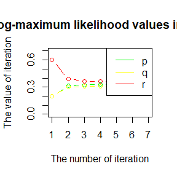

```r
x <- seq(1,k,1)
plot(x, p[1:k], "b", col = "green",ylim=c(0,0.7), main = "The log-maximum likelihood values in M-steps" , xlab = "The number of iteration", ylab = "The value of iteration")
lines(x, q[1:k], "b", col = "yellow")
lines(x, r[1:k], "b", col = "red")
legend("topright", legend = c("p", "q", "r"),lty = 1, col = c("green", "yellow", "red"))
```

# HW9(2019/12/13)

## Exercise 3(P204)

Use both for loops and lapply() to fit linear models to the mtcars using the formulas stored in this list: ## Answer

```r
formulas <- list(
mpg ~ disp,
mpg ~ I(1 / disp),
mpg ~ disp + wt,
mpg ~ I(1 / disp) + wt
)
# lapply
la1 <- lapply(formulas, lm, data = mtcars)
la2 <- lapply(formulas, function(x) lm(formula = x, data = mtcars))
# for loop
lf1 <- vector("list", length(formulas))
for (i in seq_along(formulas)){
lf1[[i]] <- lm(formulas[[i]], data = mtcars)
}
```

Note that all versions return the same content, but they won’t be identical, since the values of the “call” element will differ between each version.

## Exercise 4(P204)

Fit the model mpg ~ disp to each of the bootstrap replicates of mtcars in the list below by using a for loop and lapply() . Can you do it without an anonymous function? ## Answer

```r
bootstraps <- lapply(1:10, function(i) {
rows <- sample(1:nrow(mtcars), rep = TRUE)
mtcars[rows, ]
})
# lapply without anonymous function
la <- lapply(bootstraps, lm, formula = mpg ~ disp)
# for loop
lf <- vector("list", length(bootstraps))
for (i in seq_along(bootstraps)){
lf[[i]] <- lm(mpg ~ disp, data = bootstraps[[i]])
}
```

## Exercise 5(P204)

For each model in the previous two exercises, extract using the function below ## Answer For the models in exercise 3:

```r
rsq <- function(mod) summary(mod)$r.squared
sapply(la1, rsq)
```

```
## [1] 0.7183433 0.8596865 0.7809306 0.8838038
```

```r
sapply(la2, rsq)
```

```
## [1] 0.7183433 0.8596865 0.7809306 0.8838038
```

```r
sapply(lf1, rsq)
```

```
## [1] 0.7183433 0.8596865 0.7809306 0.8838038
```

And the models in exercise 4:

```r
sapply(la, rsq)
```

```
##  [1] 0.7346167 0.8381836 0.7103609 0.7660127 0.6183933 0.6743736 0.7546826
##  [8] 0.7292703 0.6012971 0.5931921
```

```r
sapply(lf, rsq)
```

```
##  [1] 0.7346167 0.8381836 0.7103609 0.7660127 0.6183933 0.6743736 0.7546826
##  [8] 0.7292703 0.6012971 0.5931921
```

## Exercise 3(P213)

The following code simulates the performance of a t-test for non-normal data. Use sapply() and an anonymous function to extract the p-value from every trial. ## Answer

```r
trials <- replicate(
100,
t.test(rpois(10, 10), rpois(7, 10)),
simplify = FALSE
)
# anonymous function:
sapply(trials, function(x) x[["p.value"]])
```

```
##   [1] 0.17705522 0.58311820 0.91791777 0.36122729 0.30638394 0.64369156
##   [7] 0.84603154 0.38098847 0.10898674 0.13560271 0.76855976 0.34648228
##  [13] 0.95410278 0.88484181 0.82864262 0.16711335 0.88559644 0.14657776
##  [19] 0.11373986 0.95514126 0.53033689 0.50656951 0.85020551 0.70355019
##  [25] 0.39850911 0.65733140 0.27622036 0.95231622 0.13610006 0.39056347
##  [31] 0.22442806 0.83451153 0.49842559 0.44890254 0.72635757 0.09213858
##  [37] 0.20857077 0.64703373 0.51352179 1.00000000 0.10867751 0.74240573
##  [43] 0.63389579 0.21020336 0.47126076 0.29745402 0.46640260 0.34226987
##  [49] 0.53443057 0.68326972 0.86466327 0.55362967 0.79624173 0.91960293
##  [55] 0.27985014 0.22217320 0.47377666 0.74611152 0.62819464 0.73819578
##  [61] 0.48557998 0.98332574 0.72370415 0.35899886 0.32160847 0.19065465
##  [67] 0.37053596 0.74286654 0.06084912 0.56056348 0.59866431 0.88772575
##  [73] 0.89599023 0.41924574 0.34881205 0.72051597 0.21314503 0.59514242
##  [79] 0.16347397 0.17842562 0.11420389 0.24949860 0.53305882 0.22086270
##  [85] 0.56669899 0.83623810 0.82674254 0.78596934 0.03205026 0.92974820
##  [91] 0.51374269 0.87576722 0.47102247 0.16543323 0.39897393 0.42002483
##  [97] 1.00000000 0.22699372 0.57344952 0.40106212
```

```r
# without anonymous function:
sapply(trials, "[[", "p.value")
```

```
##   [1] 0.17705522 0.58311820 0.91791777 0.36122729 0.30638394 0.64369156
##   [7] 0.84603154 0.38098847 0.10898674 0.13560271 0.76855976 0.34648228
##  [13] 0.95410278 0.88484181 0.82864262 0.16711335 0.88559644 0.14657776
##  [19] 0.11373986 0.95514126 0.53033689 0.50656951 0.85020551 0.70355019
##  [25] 0.39850911 0.65733140 0.27622036 0.95231622 0.13610006 0.39056347
##  [31] 0.22442806 0.83451153 0.49842559 0.44890254 0.72635757 0.09213858
##  [37] 0.20857077 0.64703373 0.51352179 1.00000000 0.10867751 0.74240573
##  [43] 0.63389579 0.21020336 0.47126076 0.29745402 0.46640260 0.34226987
##  [49] 0.53443057 0.68326972 0.86466327 0.55362967 0.79624173 0.91960293
##  [55] 0.27985014 0.22217320 0.47377666 0.74611152 0.62819464 0.73819578
##  [61] 0.48557998 0.98332574 0.72370415 0.35899886 0.32160847 0.19065465
##  [67] 0.37053596 0.74286654 0.06084912 0.56056348 0.59866431 0.88772575
##  [73] 0.89599023 0.41924574 0.34881205 0.72051597 0.21314503 0.59514242
##  [79] 0.16347397 0.17842562 0.11420389 0.24949860 0.53305882 0.22086270
##  [85] 0.56669899 0.83623810 0.82674254 0.78596934 0.03205026 0.92974820
##  [91] 0.51374269 0.87576722 0.47102247 0.16543323 0.39897393 0.42002483
##  [97] 1.00000000 0.22699372 0.57344952 0.40106212
```

## Exercise 7(P214)

Implement mcsapply() , a multicore version of sapply() . Can you implement mcvapply() , a parallel version of vapply() ? Why or why not? ## Answer

```r
library(parallel)
mcsapply<-function(x){
  unlist(mclapply(x, sqrt, mc.cores = 3))
}
```

My computer doesn’t support the operation of function, so I don’t know if the implement of this function is feasible.